# deRaRmarkdown.R

Esther

2019-05-27

## 1.Basics R - With solutions

### Some initial tips:

*Comments*

To write a comment, type `#` before the sentence you want to write. Anything to the right of a `#` in a script will be ignored by R.

*TIP*: To comment on a whole paragraph, select the lines you want to comment and press at the same time on your keyboard (Ctrl) + (Shift) + (c).  
*TIP*: To run any line: Click anywhere on the line you want to run and either 1) *click (Ctr)+(Enter)* or 2) *click on run bottom* (up right corner of Source/Script) If you want to run several lines, highlight them all and do as explained above.

To understand how R works, you are going to use it as a simple calcuator. You can get output in the Console simply by typing math in the script and running it:

```r
3+5
```

```
## [1] 8
```

```r
12/2
```

```
## [1] 6
```

*Assign values to objects*

`<-` assigns the values on the right to objects on the left. If we write `weight_kg <- 55`, R won’t print anything, but it creates an object called `weight_kg` with an asigned value of 55. In Rstudio, you can see this new object in the Environment window. TIP: To get `<-`, PC: Type (Alt) and (-) at the same time. Mac: (Option) and (-)

Putting parenthesis around the call prints the value of `weight_kg` automatically, as so does typing directly the name of the object (once it as been created/asigned), and running that line. Try typing `(weight_kg <- 55)` and `weight_kg`.

```r
weight_kg <- 55    # doesn't print anything, but it has created an object. You can see it in the Environment window.
(weight_kg <- 55)  # Putting parenthesis around the call prints the value of `weight_kg`
```

```
## [1] 55
```

```r
weight_kg          # and so does typing (or "calling") the name of the object
```

```
## [1] 55
```

R iS *cAsE SeNsItIvE*!!

```r
## if you try `weight_KG``, it will give you an error! (note the capitalization in KG)
```

You can override an object. *Be careful*!

```r
weight_kg <- 60
weight_kg # If you call wight_kg you see that its value is now 60. You can also see this change in the Environment window.
```

```
## [1] 60
```

Here’s some prose in a very special comment. Let’s summarize the built-in dataset `VADeaths`.

```r
## here is a regular code comment, that will remain as such
summary(VADeaths)
```

```
##    Rural Male     Rural Female     Urban Male     Urban Female
##  Min.   :11.70   Min.   : 8.70   Min.   :15.40   Min.   : 8.40
##  1st Qu.:18.10   1st Qu.:11.70   1st Qu.:24.30   1st Qu.:13.60
##  Median :26.90   Median :20.30   Median :37.00   Median :19.30
##  Mean   :32.74   Mean   :25.18   Mean   :40.48   Mean   :25.28
##  3rd Qu.:41.00   3rd Qu.:30.90   3rd Qu.:54.60   3rd Qu.:35.10
##  Max.   :66.00   Max.   :54.30   Max.   :71.10   Max.   :50.00
```

Here’s some more prose. I can use usual markdown syntax to make things **bold** or *italics*. Let’s use an example from the `dotchart()` help to make a Cleveland dot plot from the `VADeaths` data. I even bother to name this chunk, so the resulting PNG has a decent name.

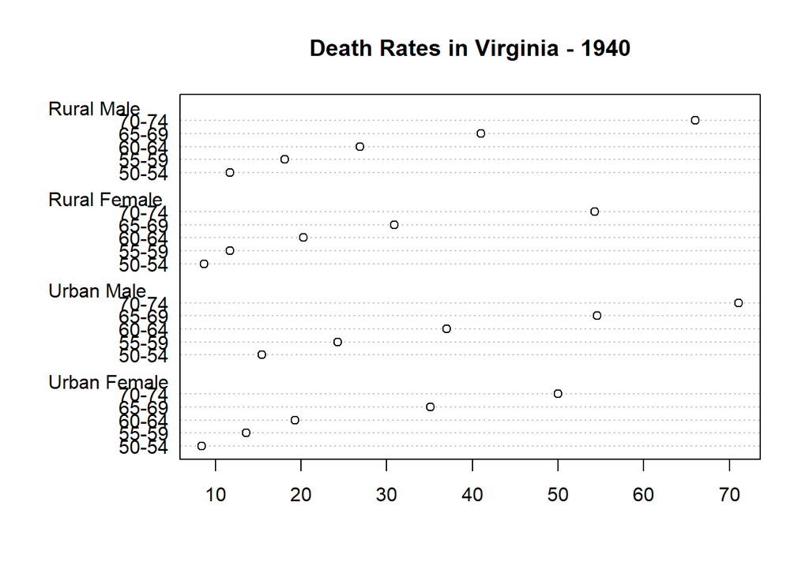

```r
dotchart(VADeaths, main = "Death Rates in Virginia - 1940")
```